# P8105_HW6_jl7035

Jeffrey Lin

2024-12-02

# Load Libraries

```r
library(tidyverse)
library(modelr)
library(mgcv)
```

# Problem 1

## Load and Clean Data

```r
weather_df =
  rnoaa::meteo_pull_monitors(
    c("USW00094728"),
    var = c("PRCP", "TMIN", "TMAX"),
    date_min = "2017-01-01",
    date_max = "2017-12-31") %>%
  mutate(
    name = recode(id, USW00094728 = "CentralPark_NY"),
    tmin = tmin / 10,
    tmax = tmax / 10) %>%
  select(name, id, everything())
```

```
## using cached file: C:\Users\jblin\AppData\Local/R/cache/R/rnoaa/noaa_ghcnd/USW00094728.dly
```

```
## date created (size, mb): 2024-09-26 10:28:49.390469 (8.668)
```

```
## file min/max dates: 1869-01-01 / 2024-09-30
```

## Peform Boostrap

```r
bootstrap_df <- weather_df %>%
  modelr::bootstrap(n = 5000) %>%
  mutate(
    models = map(strap, \(samp) lm(tmax ~ tmin, data = samp)),
    results = map(models, broom::tidy),
    summary = map(models, broom::glance),
    r_squared = map_dbl(summary, \(x) x$r.squared),
    log_beta_prod = map_dbl(results, \(x) log(prod(x$estimate)))
  ) %>%
  select(-models,-results, -summary, -strap)
```

## Distribution of R-squared

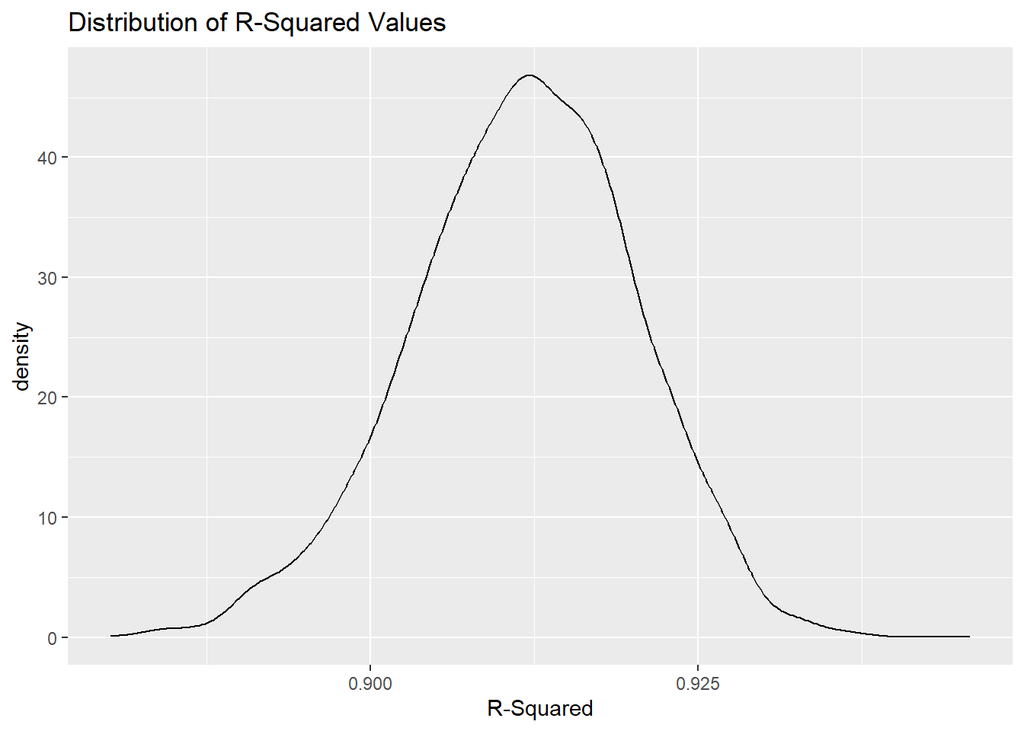

```r
bootstrap_df %>%
  ggplot(aes(x = r_squared)) +
  geom_density() +
  xlab(label = "R-Squared") +
  ggtitle(label = "Distribution of R-Squared Values")
```

Examining the distribution of R-squared values, it appears that the R-squared for a linear model with minimum temperature as a predictor of max temperature tends to center at a little above 0.91.

## Distribution of log(beta_1 * beta_0)

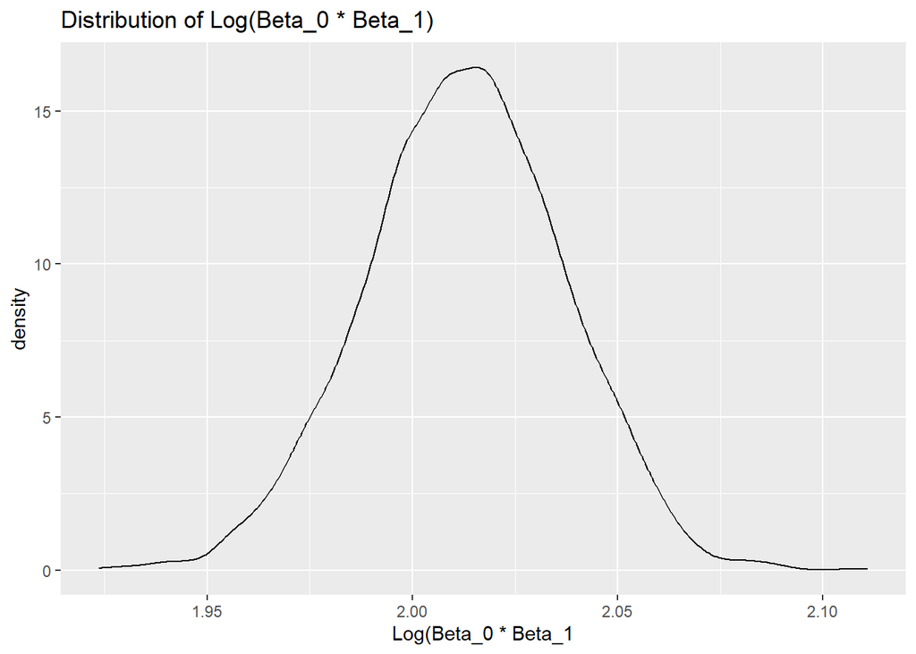

```r
bootstrap_df %>%
  ggplot(aes(x = log_beta_prod)) +
  geom_density() +
  xlab(label = "Log(Beta_0 * Beta_1") +
  ggtitle(label = "Distribution of Log(Beta_0 * Beta_1)")
```

Examining the distribution of Log(Beta_0 * Beta_1) values, it appears that the values for a linear model with minimum temperature as a predictor of max temperature tends to center between 2.00 and 2.025.

## Identify 95% confidence Interval for R-Squared

```r
bootstrap_df %>%
  summarize(
    lower_ci = quantile(r_squared, 0.025),
    upper_ci = quantile(r_squared, 0.975)
  ) %>%
  knitr::kable()
```

| lower_ci | upper_ci |
| --- | --- |
| 0.8935109 | 0.9273946 |

## Identify the 95% confidence interval of Log (Beta_0 * Beta_1)

```r
bootstrap_df %>%
  summarize(
    lower_ci = quantile(log_beta_prod, 0.025),
    upper_ci = quantile(log_beta_prod, 0.975)
  ) %>%
  knitr::kable()
```

| lower_ci | upper_ci |
| --- | --- |
| 1.964436 | 2.058836 |

# Problem 2

## Load in Data

```r
homicide_df <- read_csv(
  file = "Data/homicide-data.csv",
  na = c("NA", "",".", "na")) %>%
  drop_na() %>%
  mutate(
    city_state = str_c(city, ", ", state),
    victim_age = as.numeric(victim_age),
    victim_race = as_factor(victim_race),
    solve_status = factor(case_when(
      disposition %in% c("Closed without arrest", "Open/No arrest") ~ 0,
      disposition == "Closed by arrest" ~ 1,),
      labels = c("Unresolved", "Resolved")
    )
  ) %>%
  filter(
    !(city_state %in%
        c("Dallas, TX", "Phoenix, AZ", "Kansas City, MO", "Tulsa, AL")
      ),
    victim_race %in% c("Black", "White"),
    victim_sex %in% c("Female", "Male")
  )
```

## Prediction of Unresolved vs Resolved in Baltimore

```r
balt_log_reg <- homicide_df %>%
  filter(city_state == "Baltimore, MD") %>%
  glm(solve_status ~ victim_age + victim_sex + victim_race,
      data = .,
      family = binomial()
  )

balt_log_reg %>%
  broom::tidy(conf.int = TRUE) %>%
  filter(term == "victim_sexMale") %>%
  mutate(
    adjusted_OR = exp(estimate),
    adjusted_OR_ci_lower = exp(conf.low),
    adjusted_OR_ci_upper = exp(conf.high)
  ) %>%
  select(adjusted_OR:adjusted_OR_ci_upper, p.value) %>%
  knitr::kable()
```

| adjusted_OR | adjusted_OR_ci_lower | adjusted_OR_ci_upper | p.value |
| --- | --- | --- | --- |
| 0.4255117 | 0.3241908 | 0.5575508 | 0 |

## Logistic Regression for each City

```r
log_model_city <- homicide_df %>%
  group_by(city_state) %>%
  nest(data = -city_state) %>%
  mutate(
    models =
      map(data,
        \(x) glm(x$solve_status ~ x$victim_age + x$victim_sex + x$victim_race,
        data = .,
        family = binomial())),
    summary = map(models, \(x) broom::tidy(x, conf.int = TRUE))
  ) %>%
  unnest(summary) %>%
  filter(term == "x$victim_sexMale") %>%
  mutate(
    adjusted_OR = exp(estimate),
    adjusted_OR_ci_lower = exp(conf.low),
    adjusted_OR_ci_upper = exp(conf.high),
  ) %>%
  select(city_state, adjusted_OR:adjusted_OR_ci_upper, p.value)
```

# OR and CI of Solved Crime Rates of Men compared to Women by City

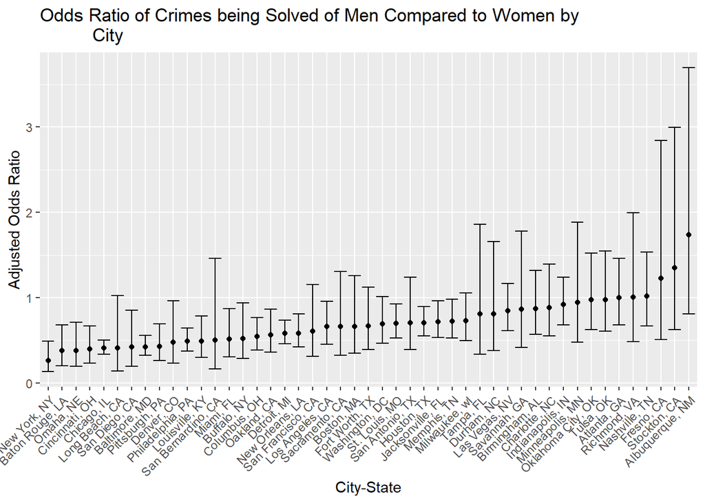

```r
log_model_city %>%
  ggplot(aes(x = reorder(city_state, adjusted_OR), y = adjusted_OR)) +
  geom_point() +
  geom_errorbar(aes(ymin = adjusted_OR_ci_lower, ymax = adjusted_OR_ci_upper)) +
  xlab(label = "City-State") +
  ylab(label = "Adjusted Odds Ratio") +
  ggtitle("Odds Ratio of Crimes being Solved of Men Compared to Women by
          City") +
  theme(axis.text.x = element_text(angle = 45, vjust = 1, hjust = 1))
```

We see the lowest adjusted odds ratio in New York City, where male victims of crimes are less likely to have their crimes resolved. Inversely, the highest odds ratio is found Albuquerque, where male victims of crimes are more likely to have their crimes resolved. It is also interesting to note that the cities with the highest adjusted odds ratios also had the largest confidence intervals. These large confidence intervals cross the threshold of 1, so it we cannot be certain at a 95% confidence level that male victims are more likely to have their crimes resolved. Also broadly, it appears that the confidence intervals are increasing as the odds ratio increases.

# Problem 3

## Load and Clean Data

```r
birthweight_df <-
  read_csv(
    file = "Data/birthweight.csv",
    na = c("NA", "na", ".", "")
  ) %>%
  janitor::clean_names() %>%
  mutate(
    babysex = factor(babysex, levels = c(1,2), labels = c("male", "female")),
    frace = factor(
      frace, levels = c(1, 2, 3, 4, 8, 9),
      labels = c("White", "Black", "Asian", "Puerto Rican", "Other", "Unknown")),
    malform = factor(
      malform, levels = c(0, 1), labels = c("absent", "present")),
    mrace = factor(
      mrace, levels = c(1, 2, 3, 4, 8),
      labels = c("White", "Black", "Asian", "Puerto Rican", "Other")
      )
  ) %>% drop_na()
```

## Rationale for Model

Considering that it is difficult to accurately hypothesize which of these predictor variables are statistically significantly and strongly associated with the outcome variable, without further background knowledge or further exploratory data analysis, I propose to take an automatic variable selection procedure. In light of the difficulty with interpreting beta coefficients produced by lasso, as well as the relatively few number of predictor variables in this data set, I propose the use of a step wise regression model. Pertaining to the step wise regression, I choose to use backwards selection to account for possible order effects that would come into play from forward selection.

## Build Model

```r
model_all_vars <- lm(bwt ~ . , data = birthweight_df)
stepwise_model <- step(model_all_vars, direction = "backward")
```

```
## Start:  AIC=48717.83
## bwt ~ babysex + bhead + blength + delwt + fincome + frace + gaweeks +
##     malform + menarche + mheight + momage + mrace + parity +
##     pnumlbw + pnumsga + ppbmi + ppwt + smoken + wtgain
##
##
## Step:  AIC=48717.83
## bwt ~ babysex + bhead + blength + delwt + fincome + frace + gaweeks +
##     malform + menarche + mheight + momage + mrace + parity +
##     pnumlbw + pnumsga + ppbmi + ppwt + smoken
##
##
## Step:  AIC=48717.83
## bwt ~ babysex + bhead + blength + delwt + fincome + frace + gaweeks +
##     malform + menarche + mheight + momage + mrace + parity +
##     pnumlbw + ppbmi + ppwt + smoken
##
##
## Step:  AIC=48717.83
## bwt ~ babysex + bhead + blength + delwt + fincome + frace + gaweeks +
##     malform + menarche + mheight + momage + mrace + parity +
##     ppbmi + ppwt + smoken
##
##            Df Sum of Sq       RSS   AIC
## - frace     4    124365 320848704 48712
## - malform   1      1419 320725757 48716
## - ppbmi     1      6346 320730684 48716
## - momage    1     28661 320752999 48716
## - mheight   1     66886 320791224 48717
## - menarche  1    111679 320836018 48717
## - ppwt      1    131132 320855470 48718
## <none>                  320724338 48718
## - fincome   1    193454 320917792 48718
## - parity    1    413584 321137922 48721
## - mrace     3    868321 321592659 48724
## - babysex   1    853796 321578134 48727
## - gaweeks   1   4611823 325336161 48778
## - smoken    1   5076393 325800732 48784
## - delwt     1   8008891 328733230 48823
## - blength   1 102050296 422774634 49915
```

[output cut: 88 more lines]

```
##     mheight + mrace + parity + ppwt + smoken
##
##           Df Sum of Sq       RSS   AIC
## <none>                 320986412 48705
## - fincome  1    245637 321232048 48707
## - parity   1    422770 321409181 48709
## - babysex  1    846134 321832545 48715
## - mheight  1   1012240 321998651 48717
## - ppwt     1   2907049 323893461 48743
## - gaweeks  1   4662501 325648912 48766
## - smoken   1   5073849 326060260 48771
## - delwt    1   8137459 329123871 48812
## - mrace    3  14683609 335670021 48894
## - blength  1 102191779 423178191 49903
## - bhead    1 106779754 427766166 49950
```

```r
summary(stepwise_model)
```

```
##
## Call:
## lm(formula = bwt ~ babysex + bhead + blength + delwt + fincome +
##     gaweeks + mheight + mrace + parity + ppwt + smoken, data = birthweight_df)
##
## Residuals:
##      Min       1Q   Median       3Q      Max
## -1097.18  -185.52    -3.39   174.14  2353.44
##
## Coefficients:
##                     Estimate Std. Error t value Pr(>|t|)
## (Intercept)       -6098.8219   137.5463 -44.340  < 2e-16 ***
## babysexfemale        28.5580     8.4549   3.378 0.000737 ***
## bhead               130.7770     3.4466  37.944  < 2e-16 ***
## blength              74.9471     2.0190  37.120  < 2e-16 ***
## delwt                 4.1067     0.3921  10.475  < 2e-16 ***
## fincome               0.3180     0.1747   1.820 0.068844 .
## gaweeks              11.5925     1.4621   7.929 2.79e-15 ***
## mheight               6.5940     1.7849   3.694 0.000223 ***
## mraceBlack         -138.7925     9.9071 -14.009  < 2e-16 ***
## mraceAsian          -74.8868    42.3146  -1.770 0.076837 .
## mracePuerto Rican  -100.6781    19.3247  -5.210 1.98e-07 ***
## parity               96.3047    40.3362   2.388 0.017004 *
## ppwt                 -2.6756     0.4274  -6.261 4.20e-10 ***
## smoken               -4.8434     0.5856  -8.271  < 2e-16 ***
## ---
## Signif. codes:  0 '***' 0.001 '**' 0.01 '*' 0.05 '.' 0.1 ' ' 1
##
## Residual standard error: 272.3 on 4328 degrees of freedom
## Multiple R-squared:  0.7181, Adjusted R-squared:  0.7173
## F-statistic: 848.1 on 13 and 4328 DF,  p-value: < 2.2e-16
```

## Function for Stepwise Regression

```r
build_stepwise = function(df) {
  model_all_vars <- lm(bwt ~ . , data = df)
  stepwise_model <- step(model_all_vars, direction = "backward")

  return(stepwise_model)
}
```

## Plot Model Predictions against Real Data

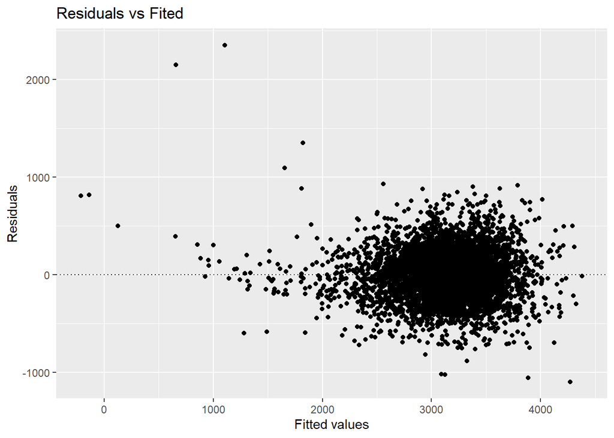

```r
birthweight_df %>%
  modelr::add_residuals(stepwise_model) %>%
  modelr::add_predictions(stepwise_model) %>%
  ggplot(aes(x = pred, y = resid)) +
  geom_point() +
  geom_hline(yintercept = 0, linetype = "dotted") +
  xlab(label = "Fitted values") +
  ylab(label = "Residuals") +
  ggtitle(label = "Residuals vs Fited")
```

Although the values are tend cluster densely between 2000 and 4000, they appear to be roughly random in location around the residual line. That is to say, there does not appear to be a pattern in the residuals and they cluster roughly horizontally.

## Length at Birth and Gestational Age Model

```r
blength_ga_model <- lm(bwt ~ blength + gaweeks, data = birthweight_df)
summary(blength_ga_model)
```

```
##
## Call:
## lm(formula = bwt ~ blength + gaweeks, data = birthweight_df)
##
## Residuals:
##     Min      1Q  Median      3Q     Max
## -1709.6  -215.4   -11.4   208.2  4188.8
##
## Coefficients:
##              Estimate Std. Error t value Pr(>|t|)
## (Intercept) -4347.667     97.958  -44.38   <2e-16 ***
## blength       128.556      1.990   64.60   <2e-16 ***
## gaweeks        27.047      1.718   15.74   <2e-16 ***
## ---
## Signif. codes:  0 '***' 0.001 '**' 0.01 '*' 0.05 '.' 0.1 ' ' 1
##
## Residual standard error: 333.2 on 4339 degrees of freedom
## Multiple R-squared:  0.5769, Adjusted R-squared:  0.5767
## F-statistic:  2958 on 2 and 4339 DF,  p-value: < 2.2e-16
```

## head circumference, length, sex model

```r
bhead_blength_sex_model <- lm(bwt ~ bhead*blength*babysex, data = birthweight_df)
summary(bhead_blength_sex_model)
```

```
##
## Call:
## lm(formula = bwt ~ bhead * blength * babysex, data = birthweight_df)
##
## Residuals:
##      Min       1Q   Median       3Q      Max
## -1132.99  -190.42   -10.33   178.63  2617.96
##
## Coefficients:
##                               Estimate Std. Error t value Pr(>|t|)
## (Intercept)                 -7176.8170  1264.8397  -5.674 1.49e-08 ***
## bhead                         181.7956    38.0542   4.777 1.84e-06 ***
## blength                       102.1269    26.2118   3.896 9.92e-05 ***
## babysexfemale                6374.8684  1677.7669   3.800 0.000147 ***
## bhead:blength                  -0.5536     0.7802  -0.710 0.478012
## bhead:babysexfemale          -198.3932    51.0917  -3.883 0.000105 ***
## blength:babysexfemale        -123.7729    35.1185  -3.524 0.000429 ***
## bhead:blength:babysexfemale     3.8781     1.0566   3.670 0.000245 ***
## ---
## Signif. codes:  0 '***' 0.001 '**' 0.01 '*' 0.05 '.' 0.1 ' ' 1
##
## Residual standard error: 287.7 on 4334 degrees of freedom
## Multiple R-squared:  0.6849, Adjusted R-squared:  0.6844
## F-statistic:  1346 on 7 and 4334 DF,  p-value: < 2.2e-16
```

## Cross Validate each Model

```r
cv_df <-
  modelr::crossv_mc(birthweight_df, 100) %>%
  mutate(
    stepwise_mod = map(train, \(df) build_stepwise(df)),
    blength_ga_mod = map(train, \(df) lm(bwt ~ blength + gaweeks, data = df)),
    head_length_sex_mod = map(train, \(df) lm(bwt ~ bhead*blength*babysex,
                                              data = df))
  ) %>%
  mutate(
    rmse_stepwise = map2_dbl(
      stepwise_mod, test, \(mod, df) rmse(model = mod, data = df)),
    rmse_blength_ga = map2_dbl(
      blength_ga_mod, test, \(mod, df) rmse(model = mod, data = df)),
    rmse_head_len_sex_mod = map2_dbl(
      head_length_sex_mod, test, \(mod, df) rmse(model = mod, data = df)
    )
  )
```

# Plot RMSE by model

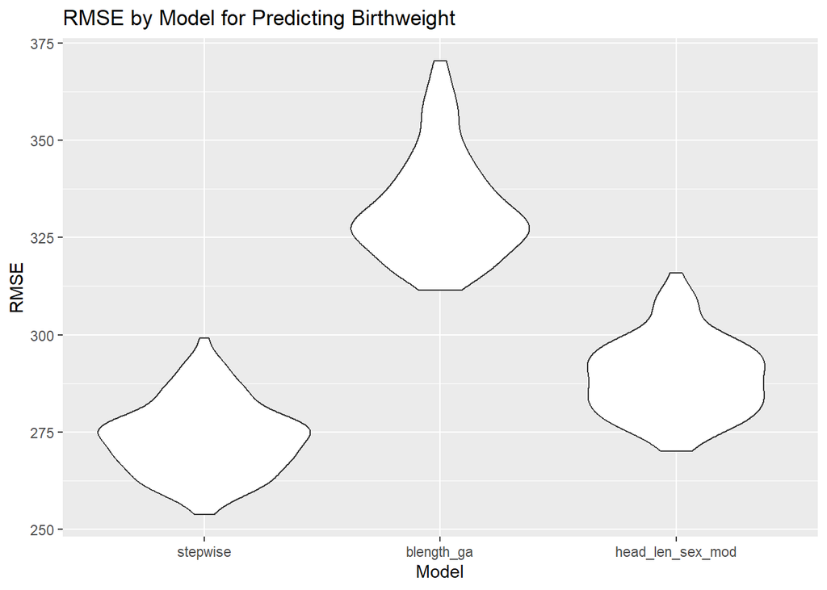

```r
cv_df %>%
  select(starts_with("rmse")) %>%
  pivot_longer(
    everything(),
    names_to = "model",
    names_prefix = "rmse_",
    values_to = "rmse"
  ) %>%
  mutate(
    model = fct_inorder(model)
  ) %>%
  ggplot(aes(x = model, y = rmse)) +
  geom_violin() +
  xlab("Model") +
  ylab("RMSE") +
  ggtitle("RMSE by Model for Predicting Birthweight")
```

Comparing the 3 models, we can see that the stepwise model outperforms both the birth length and gestational model, and the head circumference, birth length, and baby sex models. The median RMSE of the stepwise model appears to be a bit below 275, which is less than the RMSE of the head_len_sex model (~285) and the blength_ga model (~325).